# **AIML Module Project - Applied Statistics** - Total Score 60

## Variety

• Data from a variety of sources such as P&L statements, could be tracked to update our database

• Specifically, data on Social Media fan following Budget, etc could help assess the customer reach and Rol that Company X can target

• Data from specialist Basketball analytics companies such as Opta could be incorporated into this to add more attributed for analysis.

1. Structured data is data that is generally well organized and it can be easily analyzed by a machine or by humans — it has a defined length and format.
2. Semi-structured data is a form that only partially conforms to the traditional data structure (e.g. log files) — it is a mix between structured and unstructured data and because of that some parts can be easily organized and analyzed, while other parts need a machine that will sort it out.
3. Unstructured data is unorganized information that can be described as chaotic — almost 80% of all data is unstructured in nature (e.g. texts, pictures, videos, mobile data, etc).

In our case, instead of showing the data in table if we could project that as a graph image then that will be easy to interpret. For instance, we have the columns Win_Percent and Basket_Diff.

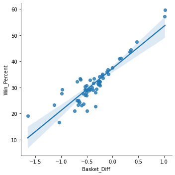

```python
sns.lmplot(y="Win_Percent", x="Basket_Diff", data=basketball_data);
```

If we try to read the dataset we wont get to know that they follow linear regression, whereas when we plot as shown above, it will be easy for us to intrepret that they both follow linear regression. By this way we can improve the variety of our data

## Veracity / Quality

• Pre-processed data will help save time for analysis (such as launch year without combinations, the derived attributes used in the calculation, using the right data type for storage)

• Additional data points such as Team Budgets, Head-to-Head records, individual match data for tournaments, Fan base, Time since last appearance in tournament are useful attributes that can be captured

• Tournament level data such as the position attained in each tournament in chronological sequence will help with accounting for recent form.

Quality and accuracy are sometimes difficult to control when it comes to gathering big data. Since big data involves a multitude of data dimensions resulting from multiple data types and sources, there is a possibility that gathered data will come with some inconsistencies and uncertainties. That is why establishing the validity of data is a crucial step that needs to be conducted before data is to be processed.

## Value

• If we are able to implement the above successfully, we can then add value by being able to predict which teams among the candidates is best by comparing Head to Head performance and recent trends.

• We will be able to predict emerging teams better if we have the information on trends and years since last appearance in the tournament.

Data by itself, regardless of its volume, usually isn’t very useful — to be valuable, it needs to be converted into insights or information, and that is where data processing steps in. By using custom processing software, you can derive useful insights from gathered data, and that can add value to your decision-making process.

In this case, just by seeing the data we can't intrepret which team has highest winning ratio as the number of games played by each team and the number of games won by each teams are different. So, If we introduce a new column `Win_Percent` which is equivalent to the fraction of number of games won to the number of games played, we can have a good insight which will be useful for us to rank the teams.

```python
basketball_data_value = basketball_data.copy(deep=True)
basketball_data_value.head()
```

|  | Team | Tournament | Score | PlayedGames | HighestPositionHeld | YearLaunch | Age | Basket_Diff | Win_Percent | Podium_Fin | SPG | Tour_Percent |
| --- | --- | --- | --- | --- | --- | --- | --- | --- | --- | --- | --- | --- |
| 0 | Team 1 | 86 | 4385 | 2762 | 1 | 1929 | 93 | 1.016293 | 59.630702 | 65.116279 | 1.587618 | 92.473118 |
| 1 | Team 2 | 86 | 4262 | 2762 | 1 | 1929 | 93 | 1.008689 | 57.241130 | 58.139535 | 1.543085 | 92.473118 |
| 2 | Team 3 | 80 | 3442 | 2614 | 1 | 1929 | 93 | 0.468630 | 47.475134 | 22.500000 | 1.316756 | 86.021505 |
| 3 | Team 4 | 82 | 3386 | 2664 | 1 | 1931 | 91 | 0.348724 | 44.557057 | 14.634146 | 1.271021 | 90.109890 |
| 4 | Team 5 | 86 | 3368 | 2762 | 1 | 1929 | 93 | 0.337075 | 43.772629 | 17.441860 | 1.219406 | 92.473118 |

```python
basketball_data_value['Win_Percent'].max()
```

```
59.630702389572775
```

```python
# Team which has highest Win_Percent
basketball_data_value.loc[(basketball_data_value['Win_Percent']) == (basketball_data_value['Win_Percent'].max())]
```

|  | Team | Tournament | Score | PlayedGames | HighestPositionHeld | YearLaunch | Age | Basket_Diff | Win_Percent | Podium_Fin | SPG | Tour_Percent |
| --- | --- | --- | --- | --- | --- | --- | --- | --- | --- | --- | --- | --- |
| 0 | Team 1 | 86 | 4385 | 2762 | 1 | 1929 | 93 | 1.016293 | 59.630702 | 65.116279 | 1.587618 | 92.473118 |

Thus, Team 1 has the highest winning ratio

```python
# Team which has lowest Win_Percent
basketball_data_value.loc[(basketball_data_value['Win_Percent']) == (basketball_data_value['Win_Percent'].min())]
```

|  | Team | Tournament | Score | PlayedGames | HighestPositionHeld | YearLaunch | Age | Basket_Diff | Win_Percent | Podium_Fin | SPG | Tour_Percent |
| --- | --- | --- | --- | --- | --- | --- | --- | --- | --- | --- | --- | --- |
| 59 | Team 60 | 1 | 14 | 30 | 15 | 1955 | 67 | -1.033333 | 16.666667 | 0.0 | 0.466667 | 1.492537 |

Thus, Team 60 has the lowest winning ratio.

By this way we can include the Value to our data.

# Part C - 15 Marks

**• DOMAIN:** Startup ecosystem

**• CONTEXT:** Company X is a EU online publisher focusing on the startups industry. The company specifically reports on the business related to technology news, analysis of emerging trends and profiling of new tech businesses and products. Their event i.e. Startup Battlefield is the world’s pre-eminent startup competition. Startup Battlefield features 15-30 top early stage startups pitching top judges in front of a vast live audience, present in person and online.

**• DATA DESCRIPTION:** CompanyX_EU.csv - Each row in the dataset is a Start-up company and the columns describe the company.

**• DATA DICTIONARY:**

1. Startup: Name of the company
2. Product: Actual product
3. Funding: Funds raised by the company in USD
4. Event: The event the company participated in
5. Result: Described by Contestant, Finalist, Audience choice, Winner or Runner up
6. OperatingState: Current status of the company, Operating ,Closed, Acquired or IPO *Dataset has been downloaded from the internet. All the credit for the dataset goes to the original creator of the data.

**• PROJECT OBJECTIVE:** Analyse the data of the various companies from the given dataset and perform the tasks that are specified in the below steps. Draw insights from the various attributes that are present in the dataset, plot distributions, state hypotheses and draw conclusions from the dataset.

#### STEPS AND TASK [15 Marks]:

### 1. Read the CSV file.

```python
# Load the necessary packages

import numpy as np
import pandas as pd

# Load the Company X Dataset

mydata_raw = pd.read_csv('CompanyX_EU.csv')
```

### 2. Data Exploration: [1 Mark]

#### A. Check the datatypes of each attribute.

```python
mydata_raw.dtypes
```

```
Startup           object
Product           object
Funding           object
Event             object
Result            object
OperatingState    object
dtype: object
```

```python
mydata_raw.info(verbose=None, buf=None, max_cols=None, memory_usage=None, show_counts=None, null_counts=None)
```

```
<class 'pandas.core.frame.DataFrame'>
RangeIndex: 662 entries, 0 to 661
Data columns (total 6 columns):
 #   Column          Non-Null Count  Dtype
---  ------          --------------  -----
 0   Startup         662 non-null    object
 1   Product         656 non-null    object
 2   Funding         448 non-null    object
 3   Event           662 non-null    object
 4   Result          662 non-null    object
 5   OperatingState  662 non-null    object
dtypes: object(6)
memory usage: 31.2+ KB
```

#### B. Check for null values in the attributes

```python
mydata_raw.applymap(lambda x: not x or pd.isnull(x)).sum()
```

```
Startup             0
Product             6
Funding           214
Event               0
Result              0
OperatingState      0
dtype: int64
```

### 3. Data preprocessing & visualisation: [4 Marks]

#### A. Drop the null values. [1 Mark]

```python
mydata=mydata_raw.dropna().copy(deep = True)
```

```python
mydata.applymap(lambda x: not x or pd.isnull(x)).sum()
```

```
Startup           0
Product           0
Funding           0
Event             0
Result            0
OperatingState    0
dtype: int64
```

Thus, the null values are dropped

```python
mydata.shape
```

```
(446, 6)
```

#### B. Convert the ‘Funding’ features to a numerical value.

(Execute below code) df1.loc[:,'Funds_in_million'] = df1['Funding'].apply(lambda x: float(x[1:-1])/1000 if x[-1] == 'K' else (float(x[1:-1])*1000 if x[-1] == 'B' else float(x[1:-1])))

```python
mydata.loc[:,'Funds_in_million'] = mydata['Funding'].apply(lambda x: float(x[1:-1])/1000 if x[-1] == 'K' else (float(x[1:-1])*1000 if x[-1] == 'B' else float(x[1:-1])))
```

```python
mydata.head()
```

|  | Startup | Product | Funding | Event | Result | OperatingState | Funds_in_million |
| --- | --- | --- | --- | --- | --- | --- | --- |
| 1 | 3DLT | 3dlt.com | $630K | Disrupt NYC 2013 | Contestant | Closed | 0.63 |
| 3 | 3Dprintler | 3dprintler.com | $1M | Disrupt NY 2016 | Audience choice | Operating | 1.00 |
| 5 | 5to1 | 5to1.com | $19.3M | TC50 2009 | Contestant | Acquired | 19.30 |
| 6 | 8 Securities | 8securities.com | $29M | Disrupt Beijing 2011 | Finalist | Operating | 29.00 |
| 10 | AdhereTech | adheretech.com | $1.8M | Hardware Battlefield 2014 | Contestant | Operating | 1.80 |

#### C. Plot box plot for funds in million. [1 Mark]

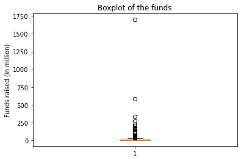

```python
plot = plt.boxplot(mydata.Funds_in_million)
plt.title('Boxplot of the funds')
plt.ylabel("Funds raised (in million)")

plt.show()
```

#### D. Check the number of outliers greater than the upper fence. [1 Mark]

```python
lower_fence = plot['caps'][0].get_data()[1][1]
lower_fence
```

```
0.005
```

```python
upper_fence = plot['caps'][1].get_data()[1][1]
upper_fence
```

```
22.0
```

```python
#Finding number of outliers beyond upper fence
q1=mydata.quantile(0.25)
q3=mydata.quantile(0.75)
IQR=q3-q1
Beyond_Upper_fence_outliers = {len(mydata[mydata.Funds_in_million>upper_fence])}
print(f'Number of outliers beyond upper fence is {len(mydata[mydata.Funds_in_million>upper_fence])}')
```

```
Number of outliers beyond upper fence is 60
```

```python
#Details of the companies that are beyond upper fence
mydata[mydata.Funds_in_million>upper_fence]
```

|  | Startup | Product | Funding | Event | Result | OperatingState | Funds_in_million |
| --- | --- | --- | --- | --- | --- | --- | --- |
| 6 | 8 Securities | 8securities.com | $29M | Disrupt Beijing 2011 | Finalist | Operating | 29.0 |
| 31 | Anyclip | anyclip.com | $24M | TC50 2009 | Finalist | Operating | 24.0 |
| 40 | Artsy | artsy.net | $50.9M | Disrupt NYC 2010 | Contestant | Operating | 50.9 |
| 49 | Badgeville | badgeville.com | $40M | Disrupt SF 2010 | Finalist | Acquired | 40.0 |
| 56 | Betterment | betterment.com | $205M | Disrupt NYC 2010 | Finalist | Operating | 205.0 |
| 108 | Clickable | clickable.com | $32.5M | TC40 2007 | Finalist | Acquired | 32.5 |
| 113 | Cloudflare | cloudflare.com | $182.1M | Disrupt SF 2010 | Runner up | Operating | 182.1 |
| 128 | Credit Sesame | creditsesame.com | $35.4M | Disrupt SF 2010 | Contestant | Operating | 35.4 |
| 130 | CrowdFlower Inc. | crowdflower.com | $38M | TC50 2009 | Contestant | Operating | 38.0 |
| 132 | Cubic Telecom | cubictelecom.com | $37.1M | TC40 2007 | Contestant | Operating | 37.1 |
| 138 | DataSift | datasift.com | $72M | Disrupt SF 2010 | Finalist | Operating | 72.0 |
| 139 | DataXu | dataxu.com | $64M | TC50 2009 | Contestant | Operating | 64.0 |
| 154 | Dropbox | dropbox.com | $1.7B | TC50 2008 | Contestant | Operating | 1700.0 |
| 166 | Enigma | enigma.io | $34.6M | Disrupt NYC 2013 | Winner | Operating | 34.6 |
| 172 | EverythingMe | everything.me | $35.5M | Disrupt NYC 2011 | Contestant | Closed | 35.5 |
| 179 | Famo.us | famo.us | $30.1M | Disrupt SF 2012 | Contestant | Operating | 30.1 |
| 180 | Farmigo | farmigo.com | $26M | Disrupt SF 2011 | Finalist | Operating | 26.0 |
| 188 | Fitbit | fitbit.com | $66M | TC50 2008 | Finalist | Ipo | 66.0 |
| 191 | Flock | flock.com | $28.3M | TC40 2007 | Contestant | Acquired | 28.3 |
| 209 | Getaround | getaround.com | $103M | Disrupt NYC 2011 | Winner | Operating | 103.0 |
| 213 | Gild | gild.com | $25.9M | Disrupt SF 2010 | Contestant | Acquired | 25.9 |
| 215 | Glide | glide.me | $36.5M | Disrupt NYC 2013 | Audience choice | Operating | 36.5 |
| 225 | Grockit | grockit.com | $44.7M | TC50 2008 | Finalist | Acquired | 44.7 |
| 231 | HackerRank | hackerrank.com | $24.2M | Disrupt SF 2012 | Contestant | Operating | 24.2 |
| 271 | Ionic Security | ionicsecurity.com | $122.4M | Disrupt SF 2012 | Contestant | Operating | 122.4 |
| 276 | IZEA | izea.com | $34.9M | Disrupt NYC 2010 | Contestant | Ipo | 34.9 |
| 279 | Jiff | jiff.com | $67.8M | Disrupt SF 2011 | Contestant | Acquired | 67.8 |
| 282 | Kaltura | kaltura.com | $166.1M | TC40 2007 | Audience choice | Operating | 166.1 |
| 302 | Layer | layer.com | $42.1M | Disrupt SF 2013 | Winner | Operating | 42.1 |
| 305 | LearnVest | learnvest.com | $69M | TC50 2009 | Contestant | Acquired | 69.0 |
| 313 | LiveIntent | liveintent.com | $65.1M | Disrupt NYC 2010 | Audience choice | Operating | 65.1 |
| 325 | Lystable | lystable.com | $25.1M | Disrupt London 2015 | Finalist | Operating | 25.1 |
| 346 | Mint | mint.com | $31.8M | TC40 2007 | Winner | Acquired | 31.8 |
| 389 | OrderWithMe | orderwithme.com | $37M | Disrupt Beijing 2011 | Winner | Operating | 37.0 |
| 393 | Osmo | playosmo.com | $38.5M | Disrupt SF 2013 | Contestant | Operating | 38.5 |
| 394 | Ossia | ossia.com | $25.5M | Disrupt SF 2013 | Runner up | Operating | 25.5 |
| 398 | Owlet Baby Care | owletcare.com | $24M | Hardware Battlefield 2014 | Runner up | Operating | 24.0 |
| 427 | Postmates | postmates.com | $278M | Disrupt SF 2011 | Contestant | Operating | 278.0 |
| 432 | Prism Skylabs | prism.com | $24M | Disrupt SF 2011 | Runner up | Operating | 24.0 |
| 435 | PubMatic | pubmatic.com | $63M | TC40 2007 | Contestant | Operating | 63.0 |
| 460 | Roadie | roadie.com | $25M | Disrupt NYC 2014 | Audience choice | Operating | 25.0 |
| 471 | SeatGeek | seatgeek.com | $160M | TC50 2009 | Contestant | Operating | 160.0 |
| 546 | StyleSeat | styleseat.com | $40M | Disrupt NYC 2011 | Contestant | Operating | 40.0 |
| 555 | Symphony Commerce | symphonycommerce.com | $47.4M | Disrupt NYC 2011 | Contestant | Operating | 47.4 |
| 560 | Talkdesk | talkdesk.com | $24.5M | Disrupt NYC 2012 | Contestant | Operating | 24.5 |
| 581 | TouchPal | touchpal.com | $25M | Disrupt Beijing 2011 | Finalist | Operating | 25.0 |
| 593 | TrueCar | truecar.com | $332.4M | TC50 2008 | Contestant | Ipo | 332.4 |
| 598 | UberConference | uberconference.com | $35M | Disrupt NYC 2012 | Winner | Operating | 35.0 |
| 606 | Upwork | upwork.com | $168.8M | TC50 2009 | Audience choice | Operating | 168.8 |
| 615 | VideoSurf | videosurf.com | $28M | TC50 2008 | Contestant | Acquired | 28.0 |
| 625 | Voxy | voxy.com | $30.8M | Disrupt SF 2010 | Contestant | Operating | 30.8 |
| 643 | Xobni | yahoo.com | $41.8M | TC40 2007 | Contestant | Acquired | 41.8 |
| 644 | Yammer | yammer.com | $142M | TC50 2008 | Winner | Acquired | 142.0 |
| 647 | Yext | yext.com | $117.8M | TC50 2009 | Contestant | Ipo | 117.8 |
| 649 | YouNow | younow.com | $26M | Disrupt SF 2011 | Contestant | Operating | 26.0 |
| 650 | YourMechanic | yourmechanic.com | $28M | Disrupt SF 2012 | Winner | Operating | 28.0 |
| 654 | ZEFR | zefr.com | $62.1M | Disrupt NYC 2010 | Contestant | Operating | 62.1 |
| 656 | Zenefits | zenefits.com | $583.6M | Disrupt NYC 2013 | Finalist | Operating | 583.6 |
| 659 | Zocdoc | zocdoc.com | $223M | TC40 2007 | Contestant | Operating | 223.0 |
| 661 | Zumper | zumper.com | $31.5M | Disrupt SF 2012 | Finalist | Operating | 31.5 |

```python
#Dropping the outliers in upper fence
mydata.drop(mydata[mydata['Funds_in_million']>upper_fence].index,inplace=True)
```

#### E. Check frequency of the OperatingState features classes. [1 Mark]

```python
mydata['OperatingState'].value_counts()
```

```
Operating    275
Closed        56
Acquired      55
Name: OperatingState, dtype: int64
```

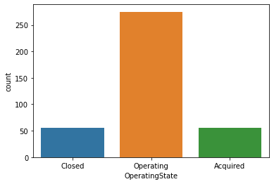

```python
sns.countplot(mydata['OperatingState'])
```

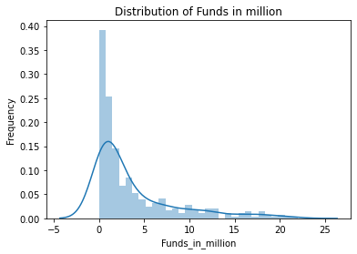

```python
sns.distplot(mydata['Funds_in_million'],bins=30,kde=True)
plt.title('Distribution of Funds in million')
plt.ylabel('Frequency')
plt.xlabel('Funds_in_million')
```

### 4. Statistical Analysis: [10 Marks]

#### A. Is there any significant difference between Funds raised by companies that are still operating vs companies that closed down? [1 Mark]

```python
mydata['Funds_in_million'].describe()
```

```
count    386.00000
mean       3.72514
std        4.73236
min        0.00500
25%        0.60000
50%        1.70000
75%        5.00000
max       22.00000
Name: Funds_in_million, dtype: float64
```

**Inference** Although data is between 0.005Mn to 22Mn, 75% of data lies below 5Mn. which implies the data is skewed

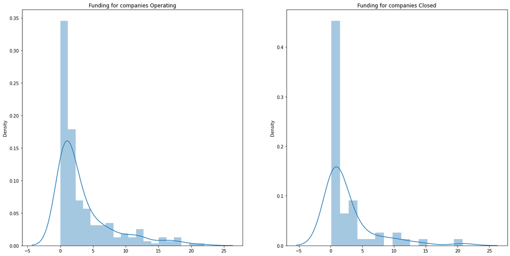

```python
#Plotting the funds dist for companies operating and closed
fig,ax = plt.subplots(1,2)

fig.set_figheight(10)
fig.set_figwidth(20)
sns.distplot(x=mydata[mydata['OperatingState']=='Operating']['Funds_in_million'],ax=ax[0])
sns.distplot(x=mydata[mydata['OperatingState']=='Closed']['Funds_in_million'],ax=ax[1])
ax[0].set_title("Funding for companies Operating")
ax[1].set_title("Funding for companies Closed")
plt.show()
```

The distributions look very similar on the plot. However, to test the significance, we will do a statistical test. We can perform two-sample z or t test here. Also, though the distributions are not normal, since our sample size > 30 we can perform z or t test

#### B. Write the null hypothesis and alternative hypothesis. [1 Mark]

In testing whether there are any significant difference between Funds raised by companies that are still operating vs companies that closed down, the null hypothesis states that difference between the funds raised by companies that are operating and companies that are closed is not significant, $\mu{O}$ equals $\mu{C}$. The alternative hypthesis states that the Funds raised by companies is different for operating and closed, $\mu{O}$ $\neq$ $\mu{C}$.

- $H_0$: $\mu{O}$ - $\mu{C}$ = 0
- $H_A$: $\mu{O}$ - $\mu{C}$ $\neq$ 0

#### C. Test for significance and conclusion [1 Mark]

```python
import scipy.stats as stats
from statsmodels.stats.weightstats import ztest
operating = mydata[mydata['OperatingState']=='Operating']['Funds_in_million']
closed = mydata[mydata['OperatingState']=='Closed']['Funds_in_million']
z_stat,p_val = ztest(operating,closed)

print('Z-statistic: ', '%1.3f' % z_stat, '\n\nP value: ',  '%1.3f' % p_val)

print('\nResult of Statistical Test:')

if p_val > 0.05:
    print('Since', '%.3f' % p_val, 'is greater than the significance level(0.05), Failed to Reject Null Hypothesis (H0) - Difference between the funds raised by companies that are operating and companies that are closed are not significant')
else:
    print('Since', '%.3f' % p_val, 'is less than the significance level(0.05), Null Hypothesis (H0) rejected - Funds raised by companies is different for operating and closed')
```

```
Z-statistic:  1.304

P value:  0.192

Result of Statistical Test:
Since 0.192 is greater than the significance level(0.05), Failed to Reject Null Hypothesis (H0) - Difference between the funds raised by companies that are operating and companies that are closed are not significant
```

```python
from scipy.stats import ttest_ind

t_stats, p_value = ttest_ind(operating,closed)
print('T-statistic: ', '%1.3f' % t_stats, '\n\nP value: ',  '%1.3f' % p_value)

print('\nResult of Statistical Test:')

if p_value > 0.05:
    print('Since', '%.3f' % p_val, 'is greater than the significance level(0.05), Failed to Reject Null Hypothesis (H0) - Difference between the funds raised by companies that are operating and companies that are closed are not significant')
else:
    print('Since', '%.3f' % p_val, 'is less than the significance level(0.05), Null Hypothesis (H0) rejected - Funds raised by companies is different for operating and closed')
```

```
T-statistic:  1.304

P value:  0.193

Result of Statistical Test:
Since 0.192 is greater than the significance level(0.05), Failed to Reject Null Hypothesis (H0) - Difference between the funds raised by companies that are operating and companies that are closed are not significant
```